# Graph drawing with netplot

George G. Vega Yon

2026-07-23

Some features:

1. Auto-scaling of vertices using sizes relative to the plotting device.
2. Embedded edge color mixer.
3. True curved edges drawing.
4. User-defined edge curvature.
5. Nicer vertex frame color.
6. Better use of space filling the plotting device.

# Introduction

```r
library(netplot)
library(igraph)
library(sna)
library(ggraph)

# We will use the UKfaculty data from the igraphdata package
data("UKfaculty", package = "igraphdata")

# With a fixed layout
set.seed(225)
l_ukf <- layout_with_fr(UKfaculty)
```

```r
# Function to map base to grid
map_base_to_grid <- function(fun) {
  gridGraphics::grid.echo(fun)
  grid::grid.grab()
}
```

```r
# Mapping base to grid
ig <- map_base_to_grid(function() plot(UKfaculty, main = "igraph"))
nw <- map_base_to_grid(function() gplot(as.matrix(as_adj(UKfaculty)), coord = l_ukf, main = "sna"))
nplot(UKfaculty, layout = l_ukf)
grid::grid.text("netplot", x = .05, y=.9)
np <- grid::grid.grab()
```

Here is an example with [`ggraph`](https://cran.r-project.org/package=ggraph)

```r
ggraph::ggraph(UKfaculty, layout = l_ukf) +
  ggraph::geom_edge_arc() +
  ggraph::geom_node_point() +
  ggplot2::ggtitle("ggraph")

gg <- grid::grid.grab()
```

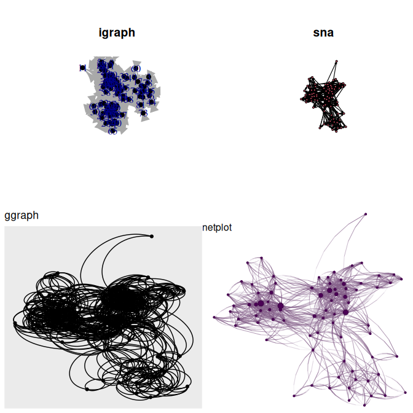

Comparison of default `igraph`, `sna`, `ggraph`, and `netplot` default call. `nplot` fills completely the plotting area, and adjusts vertex size, edge width, and edge arrows’ size accordingly to the plotting area and plotting device.

```r
# Putting all together
gridExtra::grid.arrange(ig, nw, gg, np, nrow=2, ncol=2)
```

# Multiple plots

To arrange multiple plots in the same page we can use the `grid.arrange` function from the `gridExtra` package

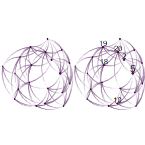

```r
x_igraph  <- sample_smallworld(1, 20, 4, .05)
x_network <- intergraph::asNetwork(x_igraph)

l <- layout_nicely(x_igraph)

# Putting two plots in the same page (one using igraph and the other network)
gridExtra::grid.arrange(
  nplot(x_igraph, layout = l),
  nplot(x_network, layout = l), ncol=2, nrow=1
)
```

# Nodes

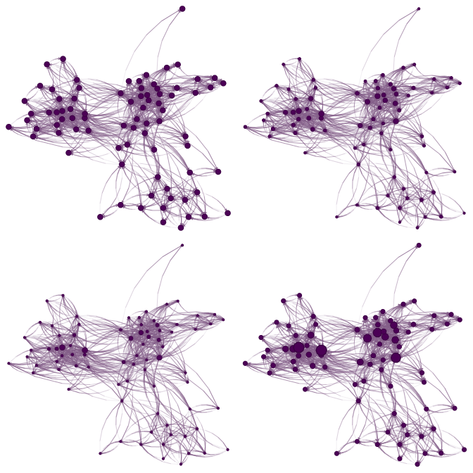

Modifying `vertex.size.range`: use `NULL` to keep the supplied vertex sizes unchanged.

```r
gridExtra::grid.arrange(
  nplot(UKfaculty, layout = l_ukf,
        vertex.size = rep(.025, vcount(UKfaculty)),
        vertex.size.range = NULL),
  nplot(UKfaculty, layout = l_ukf, vertex.size.range = c(.01, .025)),
  nplot(UKfaculty, layout = l_ukf, vertex.size.range = c(.01, .025, 4)),
  nplot(UKfaculty, layout = l_ukf, vertex.size.range = c(.02, .05, 4)),
  ncol=2, nrow=2
)
```

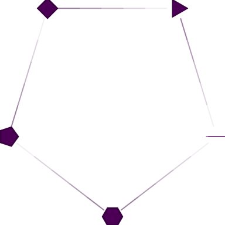

Number of sides for node drawing.

```r
nplot(make_ring(5), vertex.nsides = 2:6,
      vertex.size.range = c(.1,.1),
      edge.curvature = 0)
```

# Edges

```r
set.seed(12233)

x <- sample_smallworld(1, size = 10, nei = 2, .1)
l <- layout_with_fr(x)
```

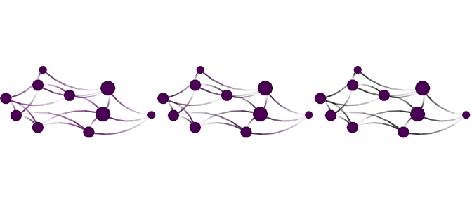

Modifying `edge.color.mix`: Each figure shows a different parameter for the edge color mixer. From left to right, (a) colors the edges as alter, (b) mixes ego and alter’s colors, and (c) only uses ego

```r
gridExtra::grid.arrange(
  nplot(
    x, layout          = l,
    edge.color        = ~ego(mix=0, alpha = .1, col="black") + alter(mix=1),
    vertex.size.range = c(.05,.1)
    ),
  nplot(
    x, layout          = l,
    edge.color        = ~ego(mix=.5, alpha = .1, col="black") + alter(mix=.5),
    vertex.size.range = c(.05,.1)
    ),
  nplot(
    x, layout          = l,
    edge.color        = ~ego(mix=1, alpha = .1, col="black") + alter(mix=0),
    vertex.size.range = c(.05,.1)
    ),
  ncol=3, nrow=1
)
```

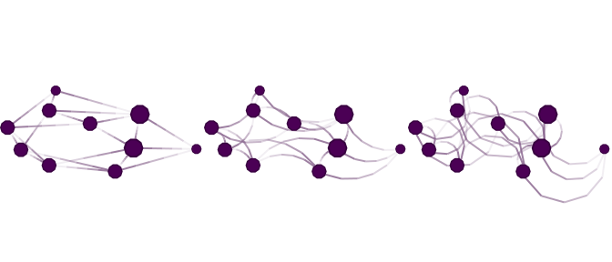

Modifying `edge.curvature`: Each figure shows a different parameter for the edge curvature. From left to right, (a) straight edges, (b) the edge between ego and alter is an arc that measures $\pi/2$ radians (90 degree), and (c) the edge as an arc between ego and alter that measures $\pi$ radians (180 degrees).

```r
gridExtra::grid.arrange(
  nplot(x, layout = l, edge.curvature = 0, vertex.size.range = c(.05,.1)),
  nplot(x, layout = l, edge.curvature = pi/2, vertex.size.range = c(.05,.1)),
  nplot(x, layout = l, edge.curvature = pi, vertex.size.range = c(.05,.1)),
  ncol = 3, nrow=1
)
```

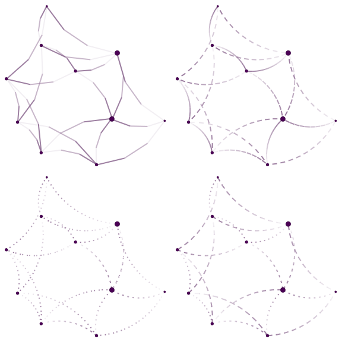

Changing the number of breaks in the edge (arc) and the type of line to be drawn.

```r
gridExtra::grid.arrange(
  nplot(x, layout = l, edge.line.breaks=3),
  nplot(x, layout = l, edge.line.lty = 2, edge.line.breaks=10),
  nplot(x, layout = l, edge.line.lty = 3, edge.line.breaks=10),
  nplot(x, layout = l, edge.line.lty = 4, edge.line.breaks=10),
  nrow=2, ncol=2
)
```

## Edge width

The `edge.width` parameter controls the relative width of each edge. Values are normalized and mapped to the range `[min, max]` specified by `edge.width.range` (in points). For `nplot.igraph`, this defaults to the `"weight"` edge attribute when present. Use `edge.width.range = NULL` to keep supplied widths unchanged.

```r
set.seed(1)
x_w <- make_ring(8)

# Assign varying edge weights
E(x_w)$weight <- c(1, 3, 1, 5, 2, 4, 1, 6)
l_w <- layout_in_circle(x_w)
```

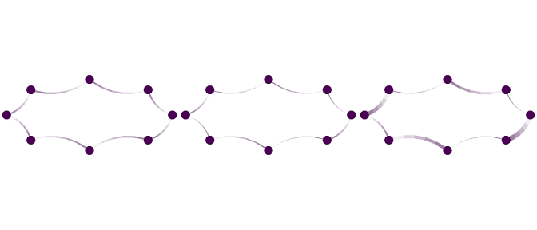

Effect of `edge.width` and `edge.width.range`. Left: uniform width. Middle: weights mapped to 1–2 pt. Right: raw weights with `edge.width.range = NULL`.

```r
gridExtra::grid.arrange(
  nplot(x_w, layout = l_w, skip.arrows = TRUE,
        vertex.size.range = c(.05, .05),
        edge.width = 1,
        edge.width.range = c(1, 2)),
  nplot(x_w, layout = l_w, skip.arrows = TRUE,
        vertex.size.range = c(.05, .05),
        edge.width = E(x_w)$weight,
        edge.width.range = c(1, 2)),
  nplot(x_w, layout = l_w, skip.arrows = TRUE,
        vertex.size.range = c(.05, .05),
        edge.width = E(x_w)$weight,
        edge.width.range = NULL),
  ncol = 3, nrow = 1
)
```

You can also modify edge widths after the plot has been created using `set_edge_gpar()`:

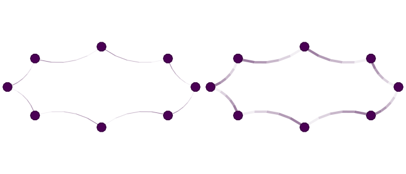

Using `set_edge_gpar()` to change edge widths after plotting. Left: all edges set to 1 pt. Right: all edges set to 4 pt.

```r
g <- nplot(x_w, layout = l_w, skip.arrows = TRUE,
           vertex.size.range = c(.05, .05))

gridExtra::grid.arrange(
  set_edge_gpar(g, element = "line", lwd = 1),
  set_edge_gpar(g, element = "line", lwd = 4),
  ncol = 2
)
```